# MNIST

```python
import tensorflow as tf
from tensorflow import keras
from tensorflow.keras.models import Sequential
from tensorflow.keras.layers import Dense, Flatten
from tensorflow.keras.datasets import mnist
```

```python
import pandas as pd
import numpy as np
import matplotlib.pyplot as plt
```

### Que. What is **MNIST** Dataset?

Ans. The MNIST database of handwritten digits has a training set of 60,000 examples, and a test set of 10,000 examples.  
It consist of digits written by high school students and employees of the United States Census Bureau, respectively.

*Four files are available:*

1. training set images
2. training set labels
3. test set images
4. test set labels

### **Sample images from MNIST test dataset**

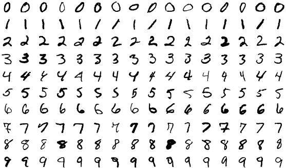

```python
(x_train, y_train), (x_test, y_test) = mnist.load_data()
```

```
Downloading data from https://storage.googleapis.com/tensorflow/tf-keras-datasets/mnist.npz
11490434/11490434 ━━━━━━━━━━━━━━━━━━━━ 0s 0us/step
```

```python
x_train.shape
```

```
(60000, 28, 28)
```

```python
x_test.shape
```

```
(10000, 28, 28)
```

```python
x_train[0].shape
```

```
(28, 28)
```

```python
pd.DataFrame(x_train[0])
```

|  | 0 | 1 | 2 | 3 | 4 | 5 | 6 | 7 | 8 | 9 | ... | 18 | 19 | 20 | 21 | 22 | 23 | 24 | 25 | 26 | 27 |
| --- | --- | --- | --- | --- | --- | --- | --- | --- | --- | --- | --- | --- | --- | --- | --- | --- | --- | --- | --- | --- | --- |
| 0 | 0 | 0 | 0 | 0 | 0 | 0 | 0 | 0 | 0 | 0 | ... | 0 | 0 | 0 | 0 | 0 | 0 | 0 | 0 | 0 | 0 |
| 1 | 0 | 0 | 0 | 0 | 0 | 0 | 0 | 0 | 0 | 0 | ... | 0 | 0 | 0 | 0 | 0 | 0 | 0 | 0 | 0 | 0 |
| 2 | 0 | 0 | 0 | 0 | 0 | 0 | 0 | 0 | 0 | 0 | ... | 0 | 0 | 0 | 0 | 0 | 0 | 0 | 0 | 0 | 0 |
| 3 | 0 | 0 | 0 | 0 | 0 | 0 | 0 | 0 | 0 | 0 | ... | 0 | 0 | 0 | 0 | 0 | 0 | 0 | 0 | 0 | 0 |
| 4 | 0 | 0 | 0 | 0 | 0 | 0 | 0 | 0 | 0 | 0 | ... | 0 | 0 | 0 | 0 | 0 | 0 | 0 | 0 | 0 | 0 |
| 5 | 0 | 0 | 0 | 0 | 0 | 0 | 0 | 0 | 0 | 0 | ... | 175 | 26 | 166 | 255 | 247 | 127 | 0 | 0 | 0 | 0 |
| 6 | 0 | 0 | 0 | 0 | 0 | 0 | 0 | 0 | 30 | 36 | ... | 225 | 172 | 253 | 242 | 195 | 64 | 0 | 0 | 0 | 0 |
| 7 | 0 | 0 | 0 | 0 | 0 | 0 | 0 | 49 | 238 | 253 | ... | 93 | 82 | 82 | 56 | 39 | 0 | 0 | 0 | 0 | 0 |
| 8 | 0 | 0 | 0 | 0 | 0 | 0 | 0 | 18 | 219 | 253 | ... | 0 | 0 | 0 | 0 | 0 | 0 | 0 | 0 | 0 | 0 |
| 9 | 0 | 0 | 0 | 0 | 0 | 0 | 0 | 0 | 80 | 156 | ... | 0 | 0 | 0 | 0 | 0 | 0 | 0 | 0 | 0 | 0 |
| 10 | 0 | 0 | 0 | 0 | 0 | 0 | 0 | 0 | 0 | 14 | ... | 0 | 0 | 0 | 0 | 0 | 0 | 0 | 0 | 0 | 0 |
| 11 | 0 | 0 | 0 | 0 | 0 | 0 | 0 | 0 | 0 | 0 | ... | 0 | 0 | 0 | 0 | 0 | 0 | 0 | 0 | 0 | 0 |
| 12 | 0 | 0 | 0 | 0 | 0 | 0 | 0 | 0 | 0 | 0 | ... | 0 | 0 | 0 | 0 | 0 | 0 | 0 | 0 | 0 | 0 |
| 13 | 0 | 0 | 0 | 0 | 0 | 0 | 0 | 0 | 0 | 0 | ... | 0 | 0 | 0 | 0 | 0 | 0 | 0 | 0 | 0 | 0 |
| 14 | 0 | 0 | 0 | 0 | 0 | 0 | 0 | 0 | 0 | 0 | ... | 25 | 0 | 0 | 0 | 0 | 0 | 0 | 0 | 0 | 0 |
| 15 | 0 | 0 | 0 | 0 | 0 | 0 | 0 | 0 | 0 | 0 | ... | 150 | 27 | 0 | 0 | 0 | 0 | 0 | 0 | 0 | 0 |
| 16 | 0 | 0 | 0 | 0 | 0 | 0 | 0 | 0 | 0 | 0 | ... | 253 | 187 | 0 | 0 | 0 | 0 | 0 | 0 | 0 | 0 |
| 17 | 0 | 0 | 0 | 0 | 0 | 0 | 0 | 0 | 0 | 0 | ... | 253 | 249 | 64 | 0 | 0 | 0 | 0 | 0 | 0 | 0 |
| 18 | 0 | 0 | 0 | 0 | 0 | 0 | 0 | 0 | 0 | 0 | ... | 253 | 207 | 2 | 0 | 0 | 0 | 0 | 0 | 0 | 0 |
| 19 | 0 | 0 | 0 | 0 | 0 | 0 | 0 | 0 | 0 | 0 | ... | 250 | 182 | 0 | 0 | 0 | 0 | 0 | 0 | 0 | 0 |
| 20 | 0 | 0 | 0 | 0 | 0 | 0 | 0 | 0 | 0 | 0 | ... | 78 | 0 | 0 | 0 | 0 | 0 | 0 | 0 | 0 | 0 |
| 21 | 0 | 0 | 0 | 0 | 0 | 0 | 0 | 0 | 23 | 66 | ... | 0 | 0 | 0 | 0 | 0 | 0 | 0 | 0 | 0 | 0 |
| 22 | 0 | 0 | 0 | 0 | 0 | 0 | 18 | 171 | 219 | 253 | ... | 0 | 0 | 0 | 0 | 0 | 0 | 0 | 0 | 0 | 0 |
| 23 | 0 | 0 | 0 | 0 | 55 | 172 | 226 | 253 | 253 | 253 | ... | 0 | 0 | 0 | 0 | 0 | 0 | 0 | 0 | 0 | 0 |
| 24 | 0 | 0 | 0 | 0 | 136 | 253 | 253 | 253 | 212 | 135 | ... | 0 | 0 | 0 | 0 | 0 | 0 | 0 | 0 | 0 | 0 |
| 25 | 0 | 0 | 0 | 0 | 0 | 0 | 0 | 0 | 0 | 0 | ... | 0 | 0 | 0 | 0 | 0 | 0 | 0 | 0 | 0 | 0 |
| 26 | 0 | 0 | 0 | 0 | 0 | 0 | 0 | 0 | 0 | 0 | ... | 0 | 0 | 0 | 0 | 0 | 0 | 0 | 0 | 0 | 0 |
| 27 | 0 | 0 | 0 | 0 | 0 | 0 | 0 | 0 | 0 | 0 | ... | 0 | 0 | 0 | 0 | 0 | 0 | 0 | 0 | 0 | 0 |

28 rows × 28 columns

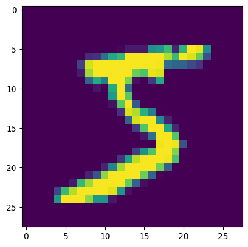

```python
plt.imshow(x_train[0])
plt.show()
```

```python
y_train[0]
```

```
5
```

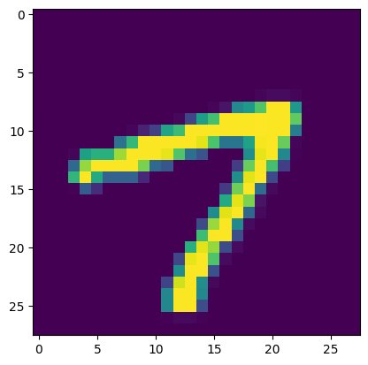

```python
plt.imshow(x_train[101])
plt.show()
```

```python
y_train[101]
```

```
7
```

```python
# Maximum and minimum pixel value
x_train.max(), x_train.min()
```

```
(255, 0)
```

Normalizing the data ensures that all features contribute equally to the learning process. Without normalization, features with larger scales or variances can dominate the optimization process, which can lead to suboptimal model performance.  
The MNIST dataset is made up of 28x28 pixel grayscale images of handwritten digits (0-9). Each pixel in the image has a value between 0 (black) and 255 (white).

```python
# normalizing
x_train = x_train/255
x_test = x_test/255
```

```python
x_train[2]
```

```
array([[0.        , 0.        , 0.        , 0.        , 0.        ,
        0.        , 0.        , 0.        , 0.        , 0.        ,
        0.        , 0.        , 0.        , 0.        , 0.        ,
        0.        , 0.        , 0.        , 0.        , 0.        ,
        0.        , 0.        , 0.        , 0.        , 0.        ,
        0.        , 0.        , 0.        ],
       [0.        , 0.        , 0.        , 0.        , 0.        ,
        0.        , 0.        , 0.        , 0.        , 0.        ,
        0.        , 0.        , 0.        , 0.        , 0.        ,
        0.        , 0.        , 0.        , 0.        , 0.        ,
        0.        , 0.        , 0.        , 0.        , 0.        ,
        0.        , 0.        , 0.        ],
       [0.        , 0.        , 0.        , 0.        , 0.        ,
        0.        , 0.        , 0.        , 0.        , 0.        ,
        0.        , 0.        , 0.        , 0.        , 0.        ,
        0.        , 0.        , 0.        , 0.        , 0.        ,
        0.        , 0.        , 0.        , 0.        , 0.        ,
        0.        , 0.        , 0.        ],
       [0.        , 0.        , 0.        , 0.        , 0.        ,
        0.        , 0.        , 0.        , 0.        , 0.        ,
        0.        , 0.        , 0.        , 0.        , 0.        ,
        0.        , 0.        , 0.        , 0.        , 0.        ,
        0.        , 0.        , 0.        , 0.        , 0.        ,
        0.        , 0.        , 0.        ],
       [0.        , 0.        , 0.        , 0.        , 0.        ,
        0.        , 0.        , 0.        , 0.        , 0.        ,
        0.        , 0.        , 0.        , 0.        , 0.        ,
        0.        , 0.        , 0.        , 0.        , 0.        ,
        0.        , 0.        , 0.        , 0.        , 0.        ,
        0.        , 0.        , 0.        ],
       [0.        , 0.        , 0.        , 0.        , 0.        ,
        0.        , 0.        , 0.        , 0.        , 0.        ,
        0.        , 0.        , 0.        , 0.        , 0.        ,
        0.        , 0.        , 0.        , 0.        , 0.        ,
        0.2627451 , 0.90980392, 0.15294118, 0.        , 0.        ,
        0.        , 0.        , 0.        ],
       [0.        , 0.        , 0.        , 0.        , 0.24313725,
        0.31764706, 0.        , 0.        , 0.        , 0.        ,
        0.        , 0.        , 0.        , 0.        , 0.        ,
        0.        , 0.        , 0.        , 0.        , 0.        ,
```

[output cut: 113 more lines]

```
        0.        , 0.        , 0.        , 0.        , 0.        ,
        0.        , 0.        , 0.        , 0.        , 0.        ,
        0.        , 0.        , 0.        ],
       [0.        , 0.        , 0.        , 0.        , 0.        ,
        0.        , 0.        , 0.        , 0.        , 0.        ,
        0.        , 0.        , 0.        , 0.        , 0.        ,
        0.        , 0.        , 0.        , 0.        , 0.        ,
        0.        , 0.        , 0.        , 0.        , 0.        ,
        0.        , 0.        , 0.        ],
       [0.        , 0.        , 0.        , 0.        , 0.        ,
        0.        , 0.        , 0.        , 0.        , 0.        ,
        0.        , 0.        , 0.        , 0.        , 0.        ,
        0.        , 0.        , 0.        , 0.        , 0.        ,
        0.        , 0.        , 0.        , 0.        , 0.        ,
        0.        , 0.        , 0.        ]])
```

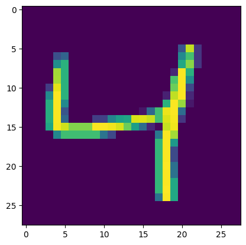

```python
plt.imshow(x_train[2])
plt.show()
```

```python
print(y_train[2])
```

```
4
```

### before creating Neural network, lets understand the input.

- Our input is a $28 \times 28$ matrix of each image which is in 2D format.
- To feed it into input layer, it must be in 1D. e.g., `[Row 1, Row 2, Row 3, .... , Row 28]`
- The shape becomes from $28 \times 28$ => $784$

```python
x_train[0].shape
```

```
(28, 28)
```

```python
x_train[0].flatten().shape
```

```
(784,)
```

So, we will use flatten layer to do this.

```python
model = Sequential()
model.add(Flatten(input_shape=(28,28)))
model.add(Dense(128, activation='relu'))
model.add(Dense(10, activation='softmax'))
```

> Whenever we have more than one output in classification, we use **softmax** as activation function. Here we have 10 outputs, from 0 to 9. Whichever output has highest probability will be our output.

```python
model.summary()
```

```
Model: "sequential"
```

```
┏━━━━━━━━━━━━━━━━━━━━━━━━━━━━━━━━━┳━━━━━━━━━━━━━━━━━━━━━━━━┳━━━━━━━━━━━━━━━┓
┃ Layer (type)                    ┃ Output Shape           ┃       Param # ┃
┡━━━━━━━━━━━━━━━━━━━━━━━━━━━━━━━━━╇━━━━━━━━━━━━━━━━━━━━━━━━╇━━━━━━━━━━━━━━━┩
│ flatten (Flatten)               │ (None, 784)            │             0 │
├─────────────────────────────────┼────────────────────────┼───────────────┤
│ dense (Dense)                   │ (None, 128)            │       100,480 │
├─────────────────────────────────┼────────────────────────┼───────────────┤
│ dense_1 (Dense)                 │ (None, 10)             │         1,290 │
└─────────────────────────────────┴────────────────────────┴───────────────┘
```

```
 Total params: 101,770 (397.54 KB)
```

```
 Trainable params: 101,770 (397.54 KB)
```

```
 Non-trainable params: 0 (0.00 B)
```

```python
(784*128 + 128) + (128*10 + 10)
```

```
101770
```

### **Loss Functions used in Categorical NN**

**1. Binary Cross-Entropy (BCE)**

Used for binary classification problems where each output is classified into one of two classes (0 or 1).

Formula is,

> $\large\text{BCE} = -\frac{1}{N} \sum_{i=1}^{N} \left[ y_i \log(\hat{y}_i) + (1 - y_i) \log(1 - \hat{y}_i) \right]$

> where,
- $y_i$ is the true label (either 0 or 1),
- $\hat{y}_i$ is the predicted probability for class 1.

**2. Categorical Cross-Entropy (CCE)**

Used for multi-class classification where the true labels are provided as one-hot encoded vectors.  
e.g., `[0, 1, 0], [1, 0, 0], [0, 0, 1]`

The formula for Categorical Cross-Entropy is:

> $\large\text{CCE} = -\frac{1}{N} \sum_{i=1}^{N} \sum_{c=1}^{C} y_{i,c} \log(\hat{y}_{i,c})$

> where,
- $y_{i,c}$ is the one-hot encoded true label for classes $c$,
- $\hat{y}_{i,c}$ is the predicted probability for classes $c$,
- $C$ is the number of classes.

**3. Sparse Categorical Cross-Entropy (SCCE)**

Similar to Categorical Cross-Entropy but used when the labels are provided as integer-encoded (not one-hot encoded).  
e.g, `[2], [3], [4]`.  
This approach is more memory-efficient, especially when dealing with a large number of classes, as it avoids the need to convert labels into one-hot vectors.

The formula for Sparse Categorical Cross-Entropy is:

> $\large\text{SCCE} = -\frac{1}{N} \sum_{i=1}^{N} \log(\hat{y}_{i, y_i})$

> where,
- $y_i$ is the true label (an integer representing the class),
- $\hat{y}_{i, y_i}$ is the predicted probability for the true class.

```python
model.compile(loss='sparse_categorical_crossentropy', optimizer='Adam', metrics=['accuracy'])
```

```python
model.fit(x_train, y_train, epochs=10, validation_split=0.2)
```

[output not shown]

```
 103/1500 ━━━━━━━━━━━━━━━━━━━━ 2s 1ms/step - accuracy: 0.6039 - loss: 1.3460
```

```
I0000 00:00:1728355213.672790     103 device_compiler.h:188] Compiled cluster using XLA!  This line is logged at most once for the lifetime of the process.
```

```
1500/1500 ━━━━━━━━━━━━━━━━━━━━ 5s 2ms/step - accuracy: 0.8664 - loss: 0.4716 - val_accuracy: 0.9561 - val_loss: 0.1503
1500/1500 ━━━━━━━━━━━━━━━━━━━━ 2s 2ms/step - accuracy: 0.9601 - loss: 0.1339 - val_accuracy: 0.9656 - val_loss: 0.1165
1500/1500 ━━━━━━━━━━━━━━━━━━━━ 2s 2ms/step - accuracy: 0.9747 - loss: 0.0867 - val_accuracy: 0.9707 - val_loss: 0.1000
1500/1500 ━━━━━━━━━━━━━━━━━━━━ 2s 2ms/step - accuracy: 0.9813 - loss: 0.0647 - val_accuracy: 0.9741 - val_loss: 0.0889
1500/1500 ━━━━━━━━━━━━━━━━━━━━ 2s 2ms/step - accuracy: 0.9850 - loss: 0.0480 - val_accuracy: 0.9696 - val_loss: 0.1009
1500/1500 ━━━━━━━━━━━━━━━━━━━━ 3s 2ms/step - accuracy: 0.9882 - loss: 0.0390 - val_accuracy: 0.9737 - val_loss: 0.0920
1500/1500 ━━━━━━━━━━━━━━━━━━━━ 2s 2ms/step - accuracy: 0.9923 - loss: 0.0273 - val_accuracy: 0.9761 - val_loss: 0.0898
1500/1500 ━━━━━━━━━━━━━━━━━━━━ 2s 2ms/step - accuracy: 0.9938 - loss: 0.0214 - val_accuracy: 0.9752 - val_loss: 0.0915
1500/1500 ━━━━━━━━━━━━━━━━━━━━ 2s 2ms/step - accuracy: 0.9950 - loss: 0.0176 - val_accuracy: 0.9755 - val_loss: 0.1002
1500/1500 ━━━━━━━━━━━━━━━━━━━━ 2s 2ms/step - accuracy: 0.9962 - loss: 0.0138 - val_accuracy: 0.9762 - val_loss: 0.0964
```

```
<keras.src.callbacks.history.History at 0x7d75281d5ae0>
```

```python
model.predict(x_test)
```

```
313/313 ━━━━━━━━━━━━━━━━━━━━ 0s 1ms/step
```

```
array([[4.5402171e-10, 3.9011885e-14, 1.2627113e-08, ..., 9.9999845e-01,
        6.0477075e-11, 9.9470270e-08],
       [4.0600745e-09, 9.3682593e-06, 9.9998939e-01, ..., 1.9862892e-16,
        5.1670783e-09, 4.7126727e-16],
       [4.6036872e-09, 9.9991131e-01, 1.1462896e-05, ..., 2.0366415e-05,
        5.1729221e-05, 3.9753708e-08],
       ...,
       [4.0942031e-16, 3.0634279e-13, 2.2202785e-18, ..., 2.6361249e-09,
        4.7078473e-11, 5.0349005e-08],
       [1.9205703e-15, 2.8721185e-15, 5.9155160e-18, ..., 1.2216892e-13,
        4.7025905e-10, 1.0100177e-15],
       [7.3391938e-11, 1.5998916e-16, 9.5018445e-11, ..., 8.5986940e-17,
        7.6379353e-14, 6.6664442e-16]], dtype=float32)
```

```python
model.predict(x_test).shape
```

```
313/313 ━━━━━━━━━━━━━━━━━━━━ 0s 1ms/step
```

```
(10000, 10)
```

```python
y_prob = model.predict(x_test)
```

```
313/313 ━━━━━━━━━━━━━━━━━━━━ 0s 1ms/step
```

```python
# to get the output in single number like 0 - 9, we need to find the index of maximum number in the array.
y_pred = y_prob.argmax(axis=1)
```

```python
y_pred
```

```
array([7, 2, 1, ..., 4, 5, 6])
```

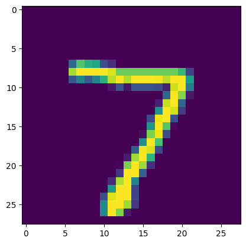

```python
plt.imshow(x_test[0])
plt.show()
```

```python
from sklearn.metrics import accuracy_score
accuracy_score(y_test, y_pred)
```

```
0.9782
```

We can improve this accuracy too, although it is good already, by changing the architecture of ANN.

```python
model2 = Sequential()
model2.add(Flatten(input_shape=(28,28)))
model2.add(Dense(128, activation='relu'))
model2.add(Dense(32, activation='relu')) # adding extra layer
model2.add(Dense(10, activation='softmax'))
```

```python
model2.summary()
```

```
Model: "sequential_1"
```

```
┏━━━━━━━━━━━━━━━━━━━━━━━━━━━━━━━━━┳━━━━━━━━━━━━━━━━━━━━━━━━┳━━━━━━━━━━━━━━━┓
┃ Layer (type)                    ┃ Output Shape           ┃       Param # ┃
┡━━━━━━━━━━━━━━━━━━━━━━━━━━━━━━━━━╇━━━━━━━━━━━━━━━━━━━━━━━━╇━━━━━━━━━━━━━━━┩
│ flatten_1 (Flatten)             │ (None, 784)            │             0 │
├─────────────────────────────────┼────────────────────────┼───────────────┤
│ dense_2 (Dense)                 │ (None, 128)            │       100,480 │
├─────────────────────────────────┼────────────────────────┼───────────────┤
│ dense_3 (Dense)                 │ (None, 32)             │         4,128 │
├─────────────────────────────────┼────────────────────────┼───────────────┤
│ dense_4 (Dense)                 │ (None, 10)             │           330 │
└─────────────────────────────────┴────────────────────────┴───────────────┘
```

```
 Total params: 104,938 (409.91 KB)
```

```
 Trainable params: 104,938 (409.91 KB)
```

```
 Non-trainable params: 0 (0.00 B)
```

```python
model2.compile(loss='sparse_categorical_crossentropy', optimizer='Adam', metrics=['accuracy'])
```

```python
history = model2.fit(x_train, y_train, epochs=25, validation_split=0.2) # increasing epochs
```

```
1500/1500 ━━━━━━━━━━━━━━━━━━━━ 3s 2ms/step - accuracy: 0.9970 - loss: 0.0084 - val_accuracy: 0.9740 - val_loss: 0.1327
1500/1500 ━━━━━━━━━━━━━━━━━━━━ 3s 2ms/step - accuracy: 0.9967 - loss: 0.0094 - val_accuracy: 0.9715 - val_loss: 0.1416
1500/1500 ━━━━━━━━━━━━━━━━━━━━ 3s 2ms/step - accuracy: 0.9974 - loss: 0.0076 - val_accuracy: 0.9763 - val_loss: 0.1414
1500/1500 ━━━━━━━━━━━━━━━━━━━━ 3s 2ms/step - accuracy: 0.9968 - loss: 0.0110 - val_accuracy: 0.9754 - val_loss: 0.1434
1500/1500 ━━━━━━━━━━━━━━━━━━━━ 3s 2ms/step - accuracy: 0.9980 - loss: 0.0068 - val_accuracy: 0.9747 - val_loss: 0.1495
1500/1500 ━━━━━━━━━━━━━━━━━━━━ 3s 2ms/step - accuracy: 0.9960 - loss: 0.0112 - val_accuracy: 0.9733 - val_loss: 0.1596
1500/1500 ━━━━━━━━━━━━━━━━━━━━ 3s 2ms/step - accuracy: 0.9976 - loss: 0.0077 - val_accuracy: 0.9756 - val_loss: 0.1586
1500/1500 ━━━━━━━━━━━━━━━━━━━━ 3s 2ms/step - accuracy: 0.9966 - loss: 0.0097 - val_accuracy: 0.9764 - val_loss: 0.1648
1500/1500 ━━━━━━━━━━━━━━━━━━━━ 3s 2ms/step - accuracy: 0.9979 - loss: 0.0072 - val_accuracy: 0.9709 - val_loss: 0.1996
1500/1500 ━━━━━━━━━━━━━━━━━━━━ 3s 2ms/step - accuracy: 0.9963 - loss: 0.0113 - val_accuracy: 0.9756 - val_loss: 0.1630
1500/1500 ━━━━━━━━━━━━━━━━━━━━ 3s 2ms/step - accuracy: 0.9971 - loss: 0.0079 - val_accuracy: 0.9778 - val_loss: 0.1535
1500/1500 ━━━━━━━━━━━━━━━━━━━━ 3s 2ms/step - accuracy: 0.9966 - loss: 0.0102 - val_accuracy: 0.9734 - val_loss: 0.1622
1500/1500 ━━━━━━━━━━━━━━━━━━━━ 3s 2ms/step - accuracy: 0.9982 - loss: 0.0060 - val_accuracy: 0.9753 - val_loss: 0.1791
1500/1500 ━━━━━━━━━━━━━━━━━━━━ 3s 2ms/step - accuracy: 0.9981 - loss: 0.0057 - val_accuracy: 0.9765 - val_loss: 0.1713
1500/1500 ━━━━━━━━━━━━━━━━━━━━ 3s 2ms/step - accuracy: 0.9971 - loss: 0.0092 - val_accuracy: 0.9756 - val_loss: 0.1758
1500/1500 ━━━━━━━━━━━━━━━━━━━━ 3s 2ms/step - accuracy: 0.9984 - loss: 0.0054 - val_accuracy: 0.9767 - val_loss: 0.1761
1500/1500 ━━━━━━━━━━━━━━━━━━━━ 3s 2ms/step - accuracy: 0.9983 - loss: 0.0065 - val_accuracy: 0.9765 - val_loss: 0.1635
1500/1500 ━━━━━━━━━━━━━━━━━━━━ 3s 2ms/step - accuracy: 0.9987 - loss: 0.0038 - val_accuracy: 0.9762 - val_loss: 0.1692
1500/1500 ━━━━━━━━━━━━━━━━━━━━ 3s 2ms/step - accuracy: 0.9984 - loss: 0.0054 - val_accuracy: 0.9752 - val_loss: 0.1825
1500/1500 ━━━━━━━━━━━━━━━━━━━━ 3s 2ms/step - accuracy: 0.9976 - loss: 0.0061 - val_accuracy: 0.9776 - val_loss: 0.1703
1500/1500 ━━━━━━━━━━━━━━━━━━━━ 3s 2ms/step - accuracy: 0.9979 - loss: 0.0061 - val_accuracy: 0.9771 - val_loss: 0.1938
1500/1500 ━━━━━━━━━━━━━━━━━━━━ 3s 2ms/step - accuracy: 0.9978 - loss: 0.0071 - val_accuracy: 0.9772 - val_loss: 0.1838
1500/1500 ━━━━━━━━━━━━━━━━━━━━ 3s 2ms/step - accuracy: 0.9979 - loss: 0.0065 - val_accuracy: 0.9758 - val_loss: 0.1950
1500/1500 ━━━━━━━━━━━━━━━━━━━━ 3s 2ms/step - accuracy: 0.9982 - loss: 0.0067 - val_accuracy: 0.9731 - val_loss: 0.2193
1500/1500 ━━━━━━━━━━━━━━━━━━━━ 3s 2ms/step - accuracy: 0.9985 - loss: 0.0042 - val_accuracy: 0.9739 - val_loss: 0.2050
```

```python
y_prob2 = model2.predict(x_test)
y_pred2 = y_prob2.argmax(axis=1)
accuracy_score(y_test, y_pred2)
```

```
313/313 ━━━━━━━━━━━━━━━━━━━━ 0s 1ms/step
```

```
0.9753
```

Accuracy is reducing due to overfitting here.

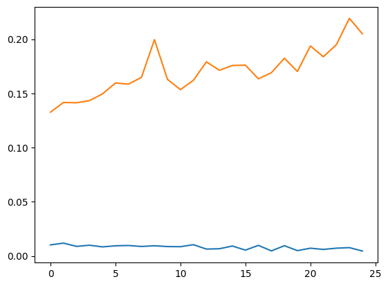

```python
plt.plot(history.history['loss'])
plt.plot(history.history['val_loss'])
```

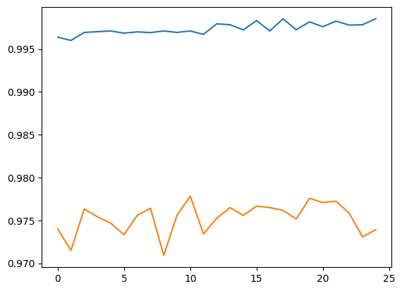

```python
plt.plot(history.history['accuracy'])
plt.plot(history.history['val_accuracy'])
```

```python
# making predictions
preds = model.predict(x_test[1].reshape(1,28,28))
```

```
1/1 ━━━━━━━━━━━━━━━━━━━━ 0s 20ms/step
```

```python
preds
```

```
array([[4.0600669e-09, 9.3682420e-06, 9.9998939e-01, 1.0303837e-07,
        7.1015532e-21, 1.1145647e-06, 8.7232038e-10, 1.9862892e-16,
        5.1670783e-09, 4.7126547e-16]], dtype=float32)
```

```python
preds.argmax(axis=1)
```

```
array([2])
```

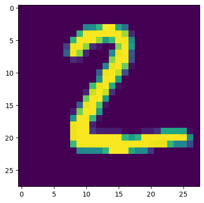

```python
plt.imshow(x_test[1])
```

```python
model.predict(x_test[100].reshape(1,28,28)).argmax(axis=1)
```

```
1/1 ━━━━━━━━━━━━━━━━━━━━ 0s 17ms/step
```

```
array([6])
```

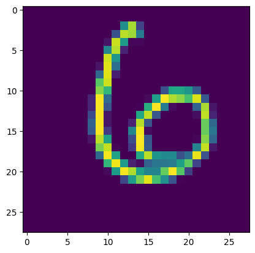

```python
plt.imshow(x_test[100])
```